# Buoy 46035

March 18, 2018

## Introduction

### In this project, we will…

- explore the data of Buoy 46035 at 57.026 N 177.738 W in the NOAA National Data Buoy Center
- look into daily Air Temperature and Sea Temperature readings at noon for the past 30 years (from 1987 to 2017).
- look at time series graphs
- test the difference between temperatures from 1987 to 2017

## Tidy

```r
Data <- MR %>%
  filter((hh == "11" & mm == "50") | (hh == "12" & mm == "00")) %>%
  mutate(ATMP = as.numeric(ATMP),
         WTMP = as.numeric(WTMP),
         MM = as.integer(MM),
         DD = as.integer(DD)) %>%
  mutate(ATMP = ifelse(ATMP > 90, NA, ATMP)) %>%
  mutate(WTMP = ifelse(WTMP > 90, NA, WTMP)) %>%
  unite("Date", c("YYYY", "MM", "DD"), sep = "-") %>%
  mutate(Date = as.Date(Date))
```

## Time Series for Air Temperature

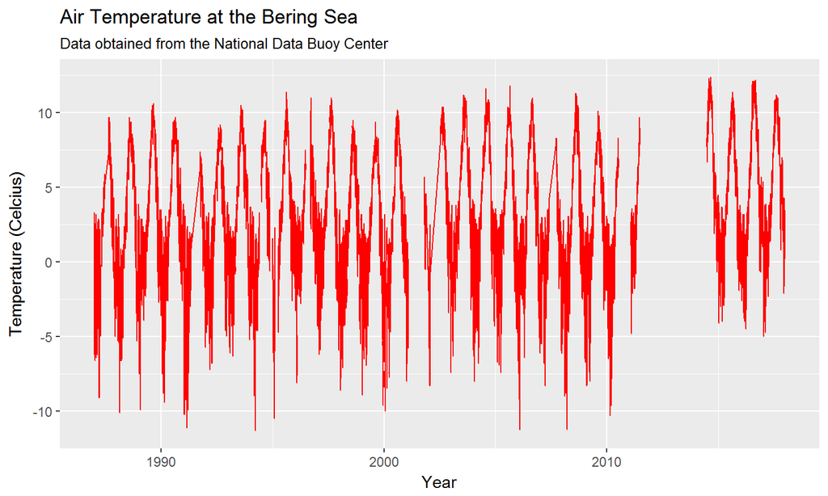

## Time Series for Sea Temperature

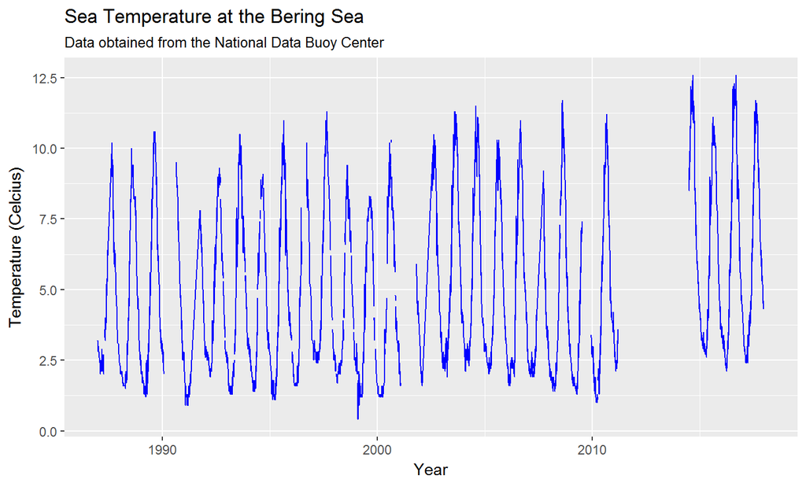

## Time Series for Both Temperatures

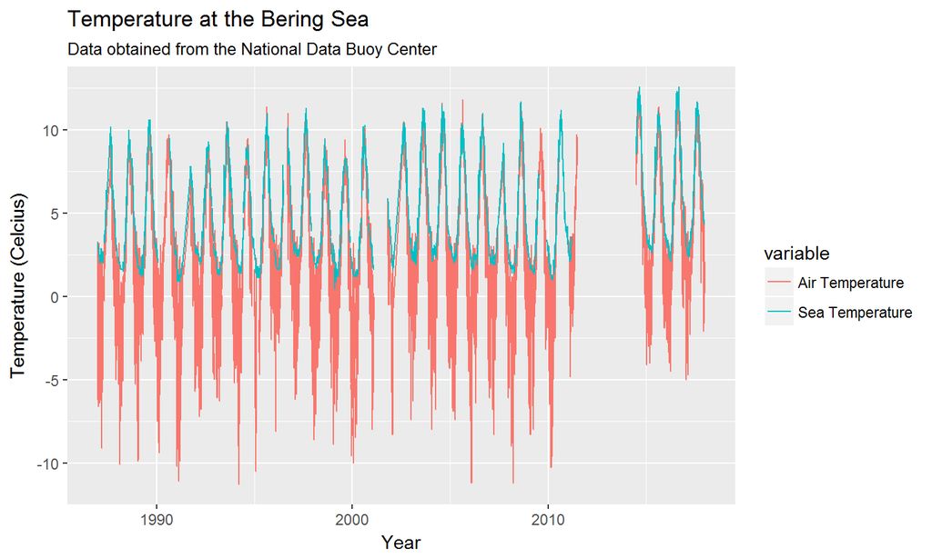

## Average Temperature per Month

### Average Air Temperature per Month in 1988

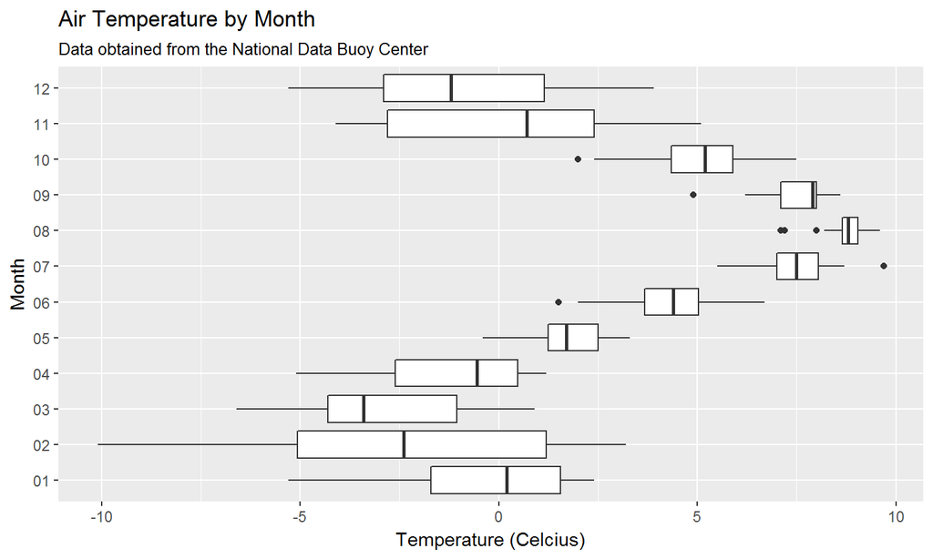

### Average Sea Temperature per Month in 1988

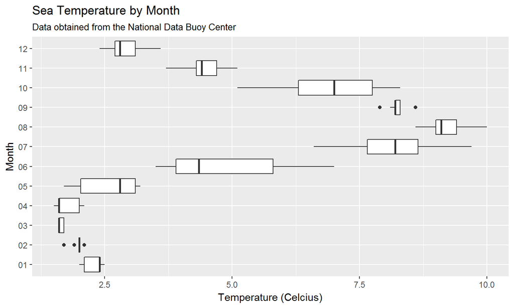

## Air and Sea Temperature Correlation

To test if Air and Sea Temperature are related to each other, we used a correlation test.

```
##
##  Pearson's product-moment correlation
##
## data:  c(ATPM, NA) and c(WTMP, NA)
## t = 164.87, df = 8281, p-value < 2.2e-16
## alternative hypothesis: true correlation is not equal to 0
## 95 percent confidence interval:
##  0.8703623 0.8804241
## sample estimates:
##       cor
## 0.8754881
```

- The output returns a correlation coefficient of 0.8754881.
- This value is close to 1, which means that there seems to be a positive relationship between air and sea temperature.
- The correlation test also calculates a p-value. If the p-value is less than 0.05, then the correlation coefficient is, in fact, significant. In this test, we got a p-value < 2.2e-16, which is also less than 0.05.
- So, the correlation coefficient of 0.8754881 is significant, confirming the positive relationship between air and sea temperature.

## Missing Data

The data that is missing has been converted to NA in the tables. When using this data to do statistical testing, there will not be an output, as NA cannot be calculated. So we omit the NA data in calculations, and proceed with the statistical testings.

## Mean Temperature Change (at noon) from 1987 to 2017

### Air Temperature

To test if mean air temperature changed over the past 30 years, we used a t-test.

Null hypothesis : mean air temperature in 1987 did not significantly change in the 30 years, so their difference would equal 0.

Alternative hypothesis : mean difference is not equal to 0, meaning there is a significant change.

```
##
##  Welch Two Sample t-test
##
## data:  x and y
## t = -9.3637, df = 616.67, p-value < 2.2e-16
## alternative hypothesis: true difference in means is not equal to 0
## 95 percent confidence interval:
##  -3.472024 -2.268153
## sample estimates:
## mean of x mean of y
##  1.775090  4.645179
```

- The mean air temperature in 1987 was 1.775090 and 4.645179 in 2017.
- The t-score is -9.3637, with a p-value < 2.2e-16, which is less than 0.05, so there is a significant change in air temperature in the last 30 years.
- The confidence interval is (-3.472024, -2.268153). 0 is not included in this interval, meaning the difference in means is not equal to 0, rejecting the null hypothesis, and confirming that there is a significant mean air temperature change in the past 30 years.

### Sea Temperature

To test if mean sea temperature changed over the past 30 years, we used a t-test.

Null hypothesis : mean sea temperature in 1987 did not significantly change in the 30 years, so their difference would equal 0.

Alternative hypothesis : mean difference is not equal to 0, meaning there is a significant change.

```
##
##  Welch Two Sample t-test
##
## data:  x and y
## t = -8.7462, df = 626.36, p-value < 2.2e-16
## alternative hypothesis: true difference in means is not equal to 0
## 95 percent confidence interval:
##  -2.196854 -1.391232
## sample estimates:
## mean of x mean of y
##  4.347482  6.141525
```

- The mean sea temperature in 1987 was 4.347482 and 6.141525 in 2017.
- The t-score is -8.7462, with a p-value < 2.2e-16, which is less than 0.05, so there is a significant change in sea temperature in the last 30 years.
- The confidence interval is (-2.196854, -1.391232). 0 is not included in this interval, meaning the difference in means is not equal to 0, rejecting the null hypothesis, and confirming that there is a significant mean sea temperature change in the past 30 years.

## Mean Temperature Change (at all times) from 1987 to 2017

### Air Temperature

To see if our sampling at only noon observations affected our evaluation of change in air temperature as a whole, we decided to take a t-test for the whole entire dataset, which includes all observations during the day, not just noon time. Our null and alternative hypotheses are the same as the previous hypotheses.

```
##
##  Welch Two Sample t-test
##
## data:  x and y
## t = -46.776, df = 14959, p-value < 2.2e-16
## alternative hypothesis: true difference in means is not equal to 0
## 95 percent confidence interval:
##  -3.047494 -2.802358
## sample estimates:
## mean of x mean of y
##  1.789408  4.714333
```

- The mean air temperature in 1987 was 1.789408 and 4.714333 in 2017, which isn't too different from the means for only noon observations. .
- The t-score is -46.776, with a p-value < 2.2e-16, which is less than 0.05, so there is a significant change in air temperature in the last 30 years.
- The confidence interval is (-3.047494, -2.802358). 0 is not included in this interval, meaning the difference in means is not equal to 0, rejecting the null hypothesis, and confirming that there is a significant mean air temperature change in the past 30 years.
- So, the sampling of only noon observations did not affect our evaluation of air temperature change in the last 30 years. In both cases, it is seen that there is a significant change.

### Sea Temperature

To see if our sampling at only noon observations affected our evaluation of change in sea temperature as a whole, we decided to take a t-test for the whole entire dataset, which includes all observations during the day, not just noon time. Our null and alternative hypotheses are the same as the previous hypotheses.

```
##
##  Welch Two Sample t-test
##
## data:  x and y
## t = -43.006, df = 15073, p-value < 2.2e-16
## alternative hypothesis: true difference in means is not equal to 0
## 95 percent confidence interval:
##  -1.884556 -1.720256
## sample estimates:
## mean of x mean of y
##  4.354448  6.156853
```

- The mean sea temperature in 1987 was 4.354448 and 6.156853 in 2017, which isn't too different from the means for only noon observations. .
- The t-score is -43.006, with a p-value < 2.2e-16, which is less than 0.05, so there is a significant change in sea temperature in the last 30 years.
- The confidence interval is (-1.884556, -1.720256). 0 is not included in this interval, meaning the difference in means is not equal to 0, rejecting the null hypothesis, and confirming that there is a significant mean sea temperature change in the past 30 years.
- So, the sampling of only noon observations did not affect our evaluation of sea temperature change in the last 30 years. In both cases, it is seen that there is a significant change.

## Conclusion

- Air temperature and Sea temperature at Buoy 46035 are significantly positively related
- Missing data is converted to NA and not included in statistical testing
- Air and sea temperature means have significantly changed in the past 30 years